# R Notebook の表題

学籍番号 氏名

2023-03-07

R Notebook は、[R Markdown](http://rmarkdown.rstudio.com) の一つの形式で、コードを実行すると、その下に実行結果が現れます。

コード・チャンクは、ハイライトされています。そのコード・チャンクは、 *Run* ボタンを押すか、コード・チャンクの右上にある、右を向いた三角形をおすか、 *Ctrl+Shift+Enter* (Win) または *Cmd+Shift+Enter* (Mac) のキーで実行できます。

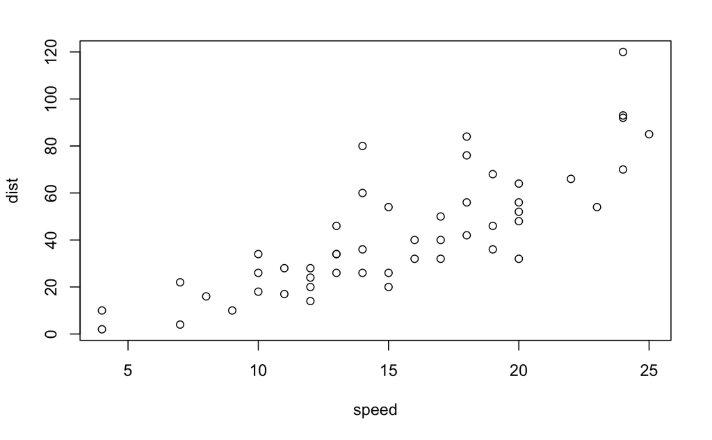

```r
plot(cars)
```

```r
str(iris)
```

```
'data.frame':   150 obs. of  5 variables:
 $ Sepal.Length: num  5.1 4.9 4.7 4.6 5 5.4 4.6 5 4.4 4.9 ...
 $ Sepal.Width : num  3.5 3 3.2 3.1 3.6 3.9 3.4 3.4 2.9 3.1 ...
 $ Petal.Length: num  1.4 1.4 1.3 1.5 1.4 1.7 1.4 1.5 1.4 1.5 ...
 $ Petal.Width : num  0.2 0.2 0.2 0.2 0.2 0.4 0.3 0.2 0.2 0.1 ...
 $ Species     : Factor w/ 3 levels "setosa","versicolor",..: 1 1 1 1 1 1 1 1 1 1 ...
```

```r
summary(iris)
```

```
  Sepal.Length    Sepal.Width     Petal.Length    Petal.Width          Species
 Min.   :4.300   Min.   :2.000   Min.   :1.000   Min.   :0.100   setosa    :50
 1st Qu.:5.100   1st Qu.:2.800   1st Qu.:1.600   1st Qu.:0.300   versicolor:50
 Median :5.800   Median :3.000   Median :4.350   Median :1.300   virginica :50
 Mean   :5.843   Mean   :3.057   Mean   :3.758   Mean   :1.199
 3rd Qu.:6.400   3rd Qu.:3.300   3rd Qu.:5.100   3rd Qu.:1.800
 Max.   :7.900   Max.   :4.400   Max.   :6.900   Max.   :2.500
```

あらたにコード・チャンクを挿入するときは、ツール・バーの *Insert Chunk* ボタンを押すか、または、 *Ctrl+Option+I* (Win) or *Cmd+Option+I* (Mac) でも可能です。

ノートブックを保存すると、コードを含む HTML ファイルが作成されます。プレビュー（*Preview* ）ボタンまたは、 *Ctrl+Shift+K* (Win) または *Cmd+Shift+K* (Mac) でも可能です。

*Knit* で他の形式の出力をするときは、最初から一つ一つコード・チャンクを実行して、その結果が出力されますが、R Notebook の、プレビューは、実際にコード・チャンクに表示されているものだけが、含まれます。したがって、たとえば、エラーがあるコード・チャンクも、そのまま表示されます。*Knit* で他の形式の出力をするときは、エラーがあると、出力されず、途中で停止します。

```r
head(iris)
```

|  | Sepal.Length | Sepal.Width | Petal.Length | Petal.Width | Species |
| --- | --- | --- | --- | --- | --- |
| 1 | 5.1 | 3.5 | 1.4 | 0.2 | setosa |
| 2 | 4.9 | 3.0 | 1.4 | 0.2 | setosa |
| 3 | 4.7 | 3.2 | 1.3 | 0.2 | setosa |
| 4 | 4.6 | 3.1 | 1.5 | 0.2 | setosa |
| 5 | 5.0 | 3.6 | 1.4 | 0.2 | setosa |
| 6 | 5.4 | 3.9 | 1.7 | 0.4 | setosa |

一つの数値ベクトルに対して、その散らばりかたは、ヒストグラムでみます。

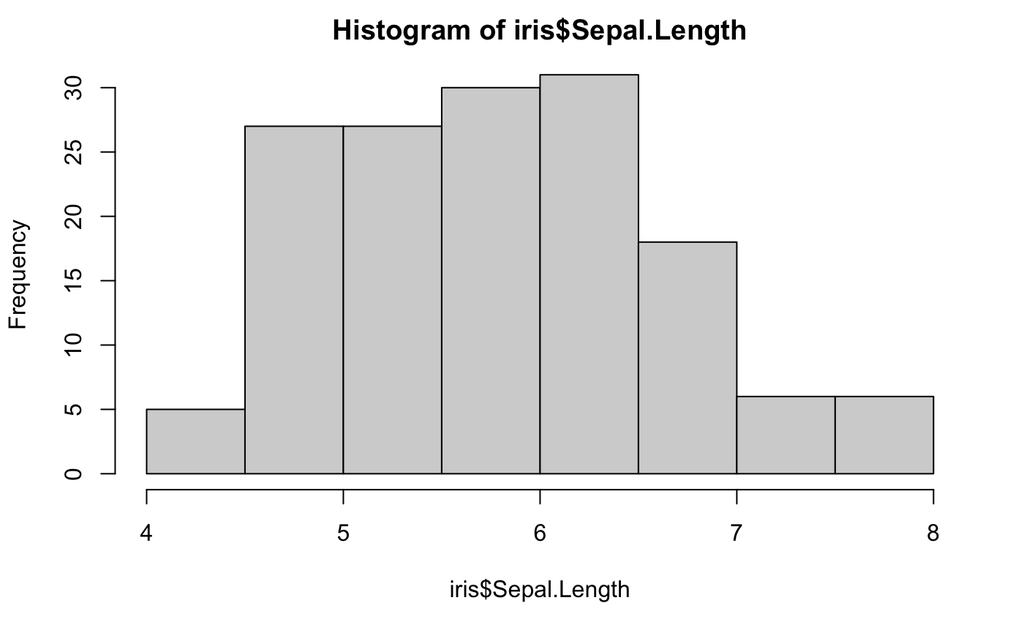

```r
hist(iris$Sepal.Length)
```

幾つに分割するかは `breaks` で指定します。

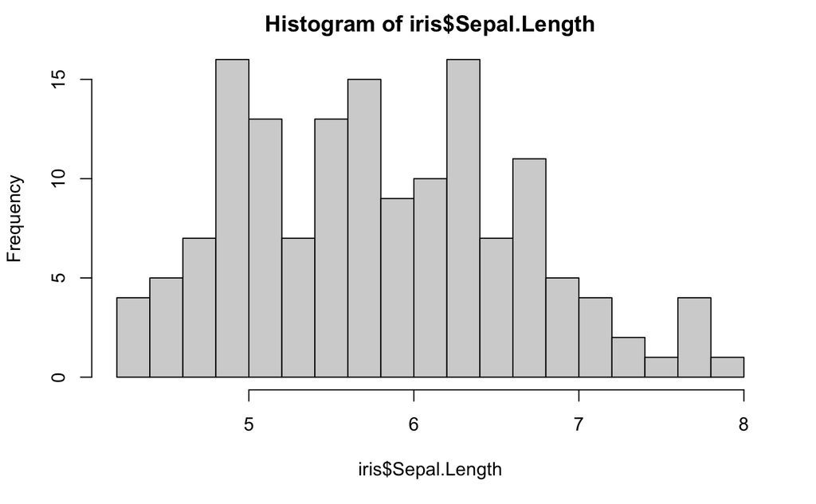

```r
hist(iris$Sepal.Length, breaks=15)
```

二つの数値ベクトルを指定すると、散布図が描けます。

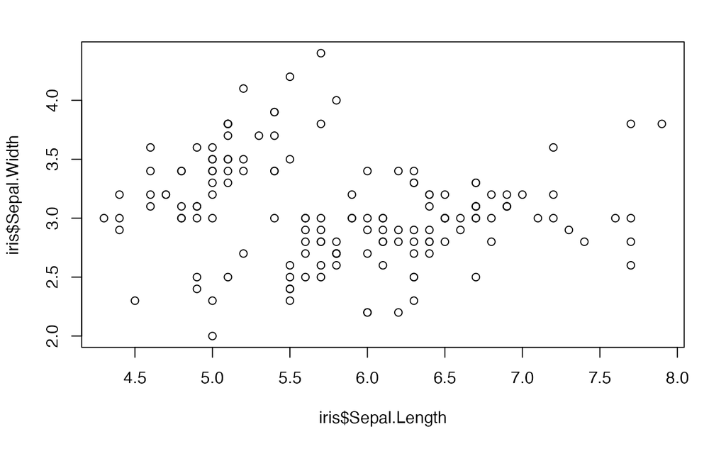

```r
plot(iris$Sepal.Length, iris$Sepal.Width)
```

下は、どんな散布図かわかりますか。

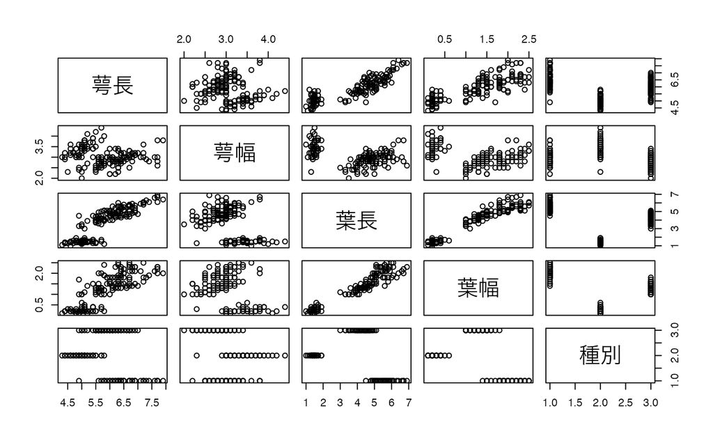

```r
plot(df_iris)
```

下のコードは、各列の相関係数（corelation）を計算するものですが、第5列目は、数値ではないので、エラーとなります。

```r
cor(iris)
```

```
Error in cor(iris) : 'x' must be numeric
```

したコードは、最初の四列だけの相関係数を求めています。

```r
cor(iris[,1:4])
```

```
             Sepal.Length Sepal.Width Petal.Length Petal.Width
Sepal.Length    1.0000000  -0.1175698    0.8717538   0.8179411
Sepal.Width    -0.1175698   1.0000000   -0.4284401  -0.3661259
Petal.Length    0.8717538  -0.4284401    1.0000000   0.9628654
Petal.Width     0.8179411  -0.3661259    0.9628654   1.0000000
```

## 練習問題

`datasets` には、`mtcars` というデータがありますが、下に、新しく、コード・チャンクを挿入して、最初の６行、データ構造（str()）、デーが概要を調べてください。Help を使ってみるのも良いですよ。ヒストグラムや、散布図も描けますか。

## スクリプト（R Script）の実行例

```r
coronavirus <- read.csv("https://github.com/RamiKrispin/coronavirus/raw/master/csv/coronavirus.csv")
head(coronavirus)
```

|  | date | province | country | lat | long | type | cases | uid | iso2 | iso3 | code3 | combined_key | population | continent_name | continent_code |
| --- | --- | --- | --- | --- | --- | --- | --- | --- | --- | --- | --- | --- | --- | --- | --- |
| 1 | 2020-01-22 | Alberta | Canada | 53.9333 | -116.5765 | confirmed | 0 | 12401 | CA | CAN | 124 | Alberta, Canada | 4413146 | North America | NA |
| 2 | 2020-01-23 | Alberta | Canada | 53.9333 | -116.5765 | confirmed | 0 | 12401 | CA | CAN | 124 | Alberta, Canada | 4413146 | North America | NA |
| 3 | 2020-01-24 | Alberta | Canada | 53.9333 | -116.5765 | confirmed | 0 | 12401 | CA | CAN | 124 | Alberta, Canada | 4413146 | North America | NA |
| 4 | 2020-01-25 | Alberta | Canada | 53.9333 | -116.5765 | confirmed | 0 | 12401 | CA | CAN | 124 | Alberta, Canada | 4413146 | North America | NA |
| 5 | 2020-01-26 | Alberta | Canada | 53.9333 | -116.5765 | confirmed | 0 | 12401 | CA | CAN | 124 | Alberta, Canada | 4413146 | North America | NA |
| 6 | 2020-01-27 | Alberta | Canada | 53.9333 | -116.5765 | confirmed | 0 | 12401 | CA | CAN | 124 | Alberta, Canada | 4413146 | North America | NA |

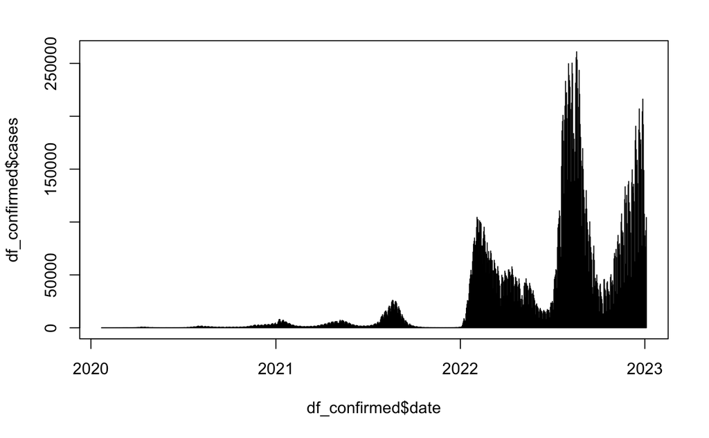

```r
coronavirus$date <- as.Date(coronavirus$date)
COUNTRY <- "Japan"
df <- coronavirus[coronavirus$country == COUNTRY,]
df_confirmed <- df[df$type == "confirmed",]
df_death <- df[df$type == "death",]
plot(df_confirmed$date, df_confirmed$cases, type = "h")
```

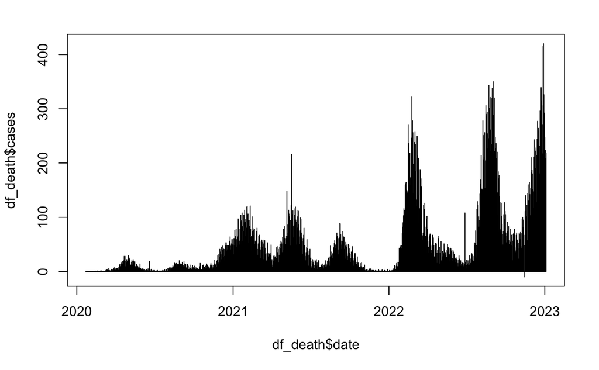

```r
plot(df_death$date, df_death$cases, type = "h")
```